# S1.6: il codice delle cellule, ripulito dei difetti noti, simula ancora gli stessi tessuti?

geo_spatialtrans, report di step (protocollo v2)

Published

October 30, 2026

# In breve

## In breve: il codice delle cellule, ripulito dei difetti noti, simula ancora gli stessi tessuti?

**A cosa serviva.** Prima di passare dalle cellule alla griglia di Visium HD dovevamo mettere in ordine il codice che costruisce le cellule: applicare le correzioni lasciate in sospeso negli step precedenti, ripulire test e ambiente, e controllare che il codice faccia quello che dice il documento di progetto. Il rischio di un lavoro così è cambiare per sbaglio i tessuti simulati. Per questo abbiamo rigenerato le 300 simulazioni di confronto e le abbiamo messe accanto a quelle di prima.

**Cosa abbiamo trovato**

1. **La simulazione predefinita dei sei tessuti è identica bit per bit a quella di prima.**
   - 300 simulazioni su 300. Le correzioni toccano solo l’opzione con le zone dei tipi cellulari, i controlli interni e i test.
   - Il controllo sulla taglia dei territori per tipo cellulare non dà più falsi allarmi nel cervello di topo: 2 avvisi su 300 simulazioni prima, nessuno ora.
2. **La semina con le zone dei tipi cellulari non impone più il numero di cellule di ogni tipo e usa un limite esatto per scartare le posizioni proposte: simula gli stessi tessuti della versione senza numero imposto provata nello step dei vuoti.**
   - Su 179 misure dei sei tessuti nessuna si sposta oltre un quarto dello scarto fra i tessuti veri: 169 confermate, 10 dove la precisione non basta per dirlo.
   - Il limite esatto è davvero in uso: si accettano dall’8 al 10 % di proposte in più in cinque tessuti e l’11 % in meno nel cervello, come calcolato prima.
3. **Nel linfonodo e nel cuore i riferimenti di taglia del nucleo per tipo cellulare ora usano gli stessi nuclei su cui stimiamo la taglia, quelli con la forma di StarDist.**
   - Con la simulazione predefinita cambia solo il cuore: le cellule più grandi fra fibroblasti e cellule immunitarie diventano un esito indeterminato.
   - Con le zone dei tipi i linfociti B migliorano e i linfociti T peggiorano. La spiegazione che avevamo scritto («le smentite dei linfociti vengono dai due insiemi di nuclei») valeva solo per i B.
4. **I «frammenti di area nulla» sui nuclei ritagliati, annotati due step fa, non esistono.**
   - Il numero annotato contava i nuclei registrati come poligoni multipli. In una simulazione lo diventano tutti appena uno solo ha due parti.
   - I nuclei davvero in due parti sono 180 su quasi due milioni e mezzo.
5. **La revisione indipendente ha trovato un errore nei test e nove punti deboli, ora corretti. I numeri ricalcolati da zero tornano.**
   - I test di uno step vecchio scrivevano ancora file nel repository. Delle 10 alterazioni del codice scritte dal revisore, 9 passavano inosservate: ora i test le vedono tutte.
   - L’ambiente si ricostruisce da zero dai pacchetti registrati: circa un minuto di installazione.

**Cosa devi decidere**

1. **Il controllo «il confronto vede le differenze vere» è fallito, come era scritto, in una misura su cinque: lo consideriamo non bloccante? Consiglio di sì.**
   - Il confronto doveva riconoscere come diverse due semine già fatte, con leggi diverse. Lo fa nella densità dell’intestino e del linfonodo, nel numero di vuoti dell’intestino e nel rapporto fra nucleo e territorio del linfonodo; in tutto in 34 misure su 179.
   - Nella densità del cervello di topo la differenza vera (circa 390 nuclei per mm²) supera solo di poco la soglia (340): con le 4 aree di tessuto confrontate l’esito resta a cavallo. L’errore è mio: scrivendo il controllo non ho confrontato la differenza attesa con la soglia.
   - Alternativa: considerarlo bloccante. Servirebbe rifare il controllo su un’altra misura; il simulatore non cambierebbe.
2. **Nei tessuti dove le cellule vengono seminate senza guardare il tipo, il controllo della taglia dei territori deve usare la densità del tessuto invece di quella del singolo tipo, cambiando il documento di progetto? Consiglio di sì.**
   - Il documento di progetto dice di usare la densità del tipo. Ma da quando i preset seminano senza guardare il tipo, ogni tipo riceve i territori del tessuto intero, e la densità del tipo è solo un numero di riferimento per la taglia del nucleo: il controllo dava avvisi senza motivo.
   - Alternativa: tenere la regola del progetto e togliere la modifica. Restano i falsi avvisi nel cervello, 2 su 300 simulazioni.

**Comunque**

- Prima di passare alla griglia di Visium HD scriveremo il README, le istruzioni del progetto e il dossier per Daniele sul codice consolidato, e uniremo il ramo delle cellule a quello di sviluppo. In quell’occasione ti chiederò l’indirizzo email da mettere come manutentore del pacchetto.
- Quando riprenderemo la semina con le zone dei tipi rifaremo la calibrazione dei vuoti con lo strumento corretto: nell’intestino il valore di oggi sta al bordo della griglia provata.
- I limiti noti delle cellule simulate sono ora scritti nel documento di progetto: troppi nuclei a contatto nel tumore del colon e nel linfonodo, territori troppo uniformi con la semina predefinita, cellule del cuore non allungate, densità riferita al tessuto pieno di cellule.

Luca ha deciso i 2 punti il 2026-10-30 («ok vai», sì a entrambi i consigli): lo step è chiuso.

**Sui tempi di calcolo.** La stima di circa 3 ore con al più 22 processori era mia, dai tempi del passo sui vuoti. Le 600 simulazioni, con raster e misure, hanno chiesto 23 minuti con 20 processori sul server del laboratorio. I test, le alterazioni del codice e la ricostruzione dell’ambiente hanno chiesto due giri di circa un’ora: il secondo dopo le correzioni chieste dalla revisione.

# Decisioni e verifiche di Luca

- «Due step: S1.6 codice, S1.6b documenti e merge» (perimetro; 2026-10-29)
- «No, step dedicato più avanti» (densità dei preset, BL-167; 2026-10-29)
- «Approvo, margine un quarto» (previsione, margine e controprove; 2026-10-29)
- «ok vai» (lettura del riassunto «In breve» senza dubbi nuovi; sì ai due consigli: CP-1 non bloccante, C7 con la densità della miscela e design §6.1 aggiornato; 2026-10-30) → S1.6: il controllo fallito come scritto non blocca lo step; C7 usa la densità della miscela nella semina cieca al tipo e il design §6.1 cambia di conseguenza (DEC-031)

# Dubbi rinviati

Ogni voce è in `docs/BACKLOG.md` con cosa serve per chiuderla.

| cosa | perché | cosa serve per chiuderlo | step destinatario | voce di BACKLOG |
| --- | --- | --- | --- | --- |
| calibrazione dei vuoti della semina a compartimenti: intestino al bordo alto della griglia; 5 pieghe su 30 cambiano ottimo con la varianza corretta | rifarla è lavoro della semina eterogenea, non del consolidamento | calibrazione con `tools/calibration_fit.py` e griglia allargata | semina eterogenea, parte 4 | BL-176 |
| limite esatto largo con il tetto della densità | il tetto non è predefinito | misura dei tempi, limite più stretto | semina eterogenea, parte 4 | BL-177 |
| metriche per tipo assenti nei semi con poche celle del tipo | metodo delle misure per tipo, ereditato | regola sui semi mancanti | da assegnare | BL-178 |
| email del manutentore nel DESCRIPTION | serve Luca | chiedere a Luca | S1.6b | BL-179 |

# Cancelli e previsioni

Pre-registrazione al commit `e262748`; ok di Luca il 2026-10-29 («Approvo, margine un quarto», commit `6dd14c3`). Codice e test al commit `1b1d11b`; banco, analisi e correzioni della revisione al commit `d066bc4`.

Bracci: **U6** semina dei preset (predefinita) col codice di S1.6, confrontata con **U** di S1.5e; **Q6** semina a compartimenti con le opzioni nuove (senza quote, limite esatto), confrontata con **Q** di S1.5e (senza quote, limite della griglia). Equivalenza: differenza appaiata per ROI (per seme in P-1 della tabella P), media ± 2 errori standard contro un margine di ± un quarto della larghezza dell’intervallo vero di S1.5e.

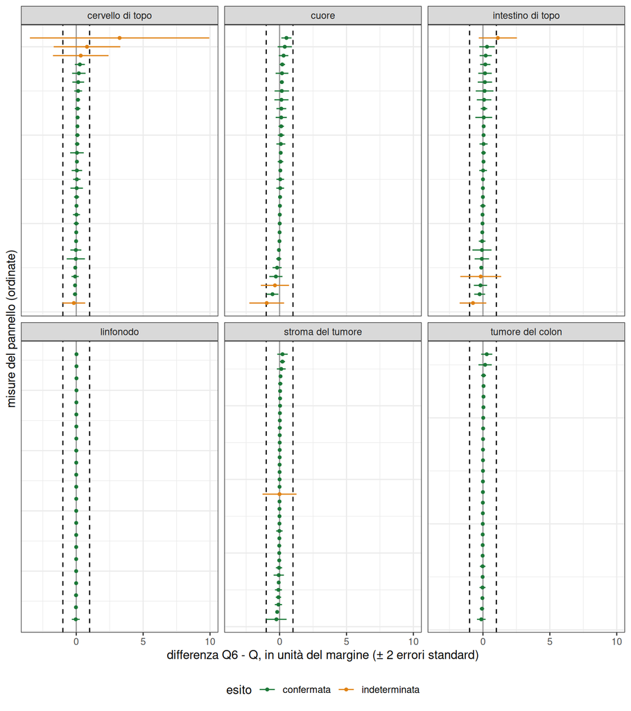

Cosa guardare: 177 stime su 179 stanno dentro ± 1 margine (linee tratteggiate); le 10 arancioni hanno la barra che esce dal margine perché l’errore standard è grande. Due stime cadono fuori dal margine, entrambe fra le righe previste imprecise da E3 e con un errore standard più grande della stima: il 90° percentile dell’area degli astrociti del cervello (3.2 margini, ± 6.7) e il rapporto mediano nucleo/territorio delle cellule immunitarie dell’intestino (1.1 margini, ± 1.4). Sono tipi rari, con poche cellule per seme.

P-1: le 10 righe non confermate (le 169 confermate nel file S1.6_P1.csv)

| tessuto | misura | unità | coppie | differenza | margine | esito | prevista indeterminata (E3) |
| --- | --- | --- | --- | --- | --- | --- | --- |
| intestino di topo | P-5 | epiteliale | 5 | -0.001246 ± 0.00166 | ± 0.001666 | indeterminata | True |
| intestino di topo | P-6 | stromale e muscolo liscio 10-20 | 5 | -0.00331 ± 0.0304 | ± 0.01987 | indeterminata | True |
| intestino di topo | P-4 | immunitario | 5 | 0.003724 ± 0.00478 | ± 0.003351 | indeterminata | True |
| stroma del tumore | P-1 | tessuto | 10 | -0.0002754 ± 0.0635 | ± 0.05 | indeterminata | True |
| cervello di topo | P-6 | astrociti 40-80 | 5 | -0.02759 ± 0.131 | ± 0.1539 | indeterminata | False |
| cervello di topo | P-8b | astrociti | 5 | 0.4787 ± 2.94 | ± 1.417 | indeterminata | True |
| cervello di topo | P-6 | astrociti 10-20 | 5 | 0.2538 ± 0.787 | ± 0.3159 | indeterminata | True |
| cervello di topo | P-14 | astrociti | 5 | 4.946 ± 10.2 | ± 1.526 | indeterminata | True |
| cuore | P-1 | tessuto | 10 | -0.01685 ± 0.0227 | ± 0.0175 | indeterminata | True |
| cuore | P-16 | tessuto | 5 | -0.02224 ± 0.0672 | ± 0.06371 | indeterminata | False |

# Controprove

CP-1: le 5 righe pre-registrate del confronto XA - RV di S1.5e (attese smentite)

| tessuto | misura | differenza | margine | esito |
| --- | --- | --- | --- | --- |
| intestino di topo | P-15 | -2445 ± 71.4 | ± 386.9 | smentita |
| intestino di topo | P-17 | -44.34 ± 5.39 | ± 5.25 | smentita |
| linfonodo | P-3 | -0.08227 ± 0.00775 | ± 0.01304 | smentita |
| linfonodo | P-15 | -9163 ± 806 | ± 2303 | smentita |
| cervello di topo | P-15 | -389.5 ± 54.1 | ± 339.6 | indeterminata |

CP-1: esiti delle 179 righe del confronto XA - RV

| esito | righe |
| --- | --- |
| confermata | 96 |
| indeterminata | 49 |
| smentita | 34 |

CP-2: quota di proposte accettate dal diradamento, Q6 su Q; bound_ratio_E4 = limite esatto / limite della griglia

| archetype | acc_Q6 | acc_Q | ratio | bound_ratio_E4 | expected | ok |
| --- | --- | --- | --- | --- | --- | --- |
| A1 | 0.325 | 0.295 | 1.102 | 0.909 | > 1.05 | True |
| A2 | 0.465 | 0.423 | 1.100 | 0.909 | > 1.05 | True |
| A3 | 0.240 | 0.218 | 1.100 | 0.909 | > 1.05 | True |
| A4 | 0.878 | 0.811 | 1.082 | 0.924 | > 1.05 | True |
| A5 | 0.216 | 0.244 | 0.888 | 1.176 | < 0.95 | True |
| A6 | 0.301 | 0.274 | 1.099 | 0.910 | > 1.05 | True |

# Dopo il risultato: cancelli, correzioni e revisione avversariale

Scritto dopo il banco, le controprove, i cancelli e la revisione avversariale; le correzioni chieste dalla revisione sono applicate e i cancelli G-1, G-2, G-3 (riesecuzione) e G-4 sono stati rifatti dopo di esse (commit `d066bc4`). Ogni numero viene da un file di `results/S1.6/` o dai log in `/mnt/micron/geo_spatialtrans/S1.6/` indicati accanto.

### Cancelli

| id | esito | dettaglio |
| --- | --- | --- |
| G-1 | PASS | `test_S1.6.R` 23/23 (15 pre-registrate più T1c, T2e, T2f, T3c, T3d, T4d, T4e, T4f dopo la revisione); `tools/test_calibration_fit.py` 8/8; batteria di S1.4f con tutte le precedenti e i soli FAIL noti:… |
| G-2 | PASS | mutanti di S1.6 16/16 (N1-N6 pre-registrati, N7-N16 = i 10 mutanti del revisore, prima rilevati 1/10), S1.5 9/9, S1.5b 8/8 come copie modificate del codice (`tests2/G2.log`). |
| G-3 | PASS | `S1.6_G3_check.csv`: 600 unità senza ERROR in C2, C3, C5, C9; semina dei preset U6 = U di S1.5e (md5) 300/300; nella semina a compartimenti Q6 0 superamenti del limite, limite esatto in tutte le regio… |
| G-4 | **FAIL come scritto**, poi PASS dopo la correzione dello strumento (D-1) | `Imports` = pacchetti usati in `R/*.R` (14); dipendenze dedotte e non installate 0; restore da zero: 189 pacchetti scaricati e installati in 64 s, quasi tutti binari Posit (`cluster` compilato dal sor… |
| G-5 | PASS per il ricalcolo; rilievi chiusi sotto | revisore dei numeri: 117 voci, 101 identiche, 14 entro 1e-9 (massimo 1.8e-12), 1 uguale al valore arrotondato, 1 discrepanza di conteggio nell’istogramma di E2 (RN-02); revisore del codice: 21 rilievi… |

### Controprove

- **CP-1, fallita come scritta in 1 riga su 5** (`S1.6_CP1.csv`). Il confronto XA meno RV di S1.5e è smentito, come atteso, nella densità del ROI dell’intestino (-2 445 nuclei/mm², margine 387) e del linfonodo (-9 163, margine 2 303), nel numero di vuoti dell’intestino (-44.3, margine 5.25) e nel rapporto nucleo/territorio del linfonodo (-0.082, margine 0.013); nella densità del cervello è indeterminato: -389.5 ± 54.1 contro un margine di ± 339.6. In tutto il confronto le smentite sono 34 su 179: il confronto non è cieco. Errore di pre-registrazione: la differenza attesa del cervello (XA 795 contro RV 1 185, valori di S1.5e noti prima) non era stata confrontata con il margine; supera il margine solo del 15 %, meno di 2 errori standard. Decisione di Luca: non blocca (DEC-031).
- **CP-2, superata** (`S1.6_CP2.csv`): quota di proposte accettate dal diradamento, Q6 su Q, 1.102 intestino, 1.100 tumore del colon, 1.100 stroma, 1.082 linfonodo, 1.099 cuore (attese > 1.05) e 0.888 cervello (attesa < 0.95); i rapporti dei limiti di E4 davano 1/0.909 = 1.10 e 1/1.176 = 0.85.

### Descrittive

- D-1 (`S1.6_desc.csv`): tempo mediano per unità di Q6 uguale a Q entro l’1-4 % (intestino 39.1 contro 39.2 s, cervello 22.0 contro 22.1 s); U6 dal 4 al 18 % più veloce di U di S1.5e (intestino 29.0 contro 30.5 s, stroma 3.1 contro 3.8 s), la stessa semina con md5 identici: la differenza è del carico del server.
- D-2 (`S1.6_verdicts.csv`, `S1.6_counts.csv`): con i riferimenti per tipo nuovi, U6 69 confermate, 16 indeterminate, 94 smentite su 179 (U di S1.5e con gli stessi riferimenti: identici, 0 esiti diversi); Q6 119, 17, 43 (Q di S1.5e con gli stessi riferimenti 119, 19, 41: 6 esiti diversi, tutti a cavallo di un estremo). Conferme spaziali e per tipo di Q6: 60 e 48, come Q.
- D-3: frazione realizzata dei tipi, scarto massimo da RV (con le quote) 0.021 in Q6 e 0.021 in Q di S1.5e; fra Q6 e Q 0.004.
- D-4: E5 (5 pieghe su 30 cambiano ottimo con la varianza corretta; nessuna nuova calibrazione in S1.6, BL-176).

### Correzioni e note

- **D-1, controllo del restore (G-4).** Il controllo pre-registrato cercava ogni pacchetto del lockfile nella libreria nuova; i pacchetti raccomandati di R alla versione registrata stanno nella libreria di sistema e renv non li reinstalla. Il controllo ora accetta i pacchetti raccomandati della libreria di sistema alla versione registrata (`tools/S1.6_env_check.R`); errore dello strumento, corretto e rieseguito.
- **D-2, tre asserzioni di G-1 spostate** (revisione RC-17): la riproduzione di unità RV e Q di S1.5e per md5 è in G-3 (8 unità invece di 3+3, PASS); «0 WARN di C7 nel cervello» è nel controllo del banco (0 contro 2); l’opzione dei preset a un tipo è verificata da T3d (md5) e dalla batteria di S1.5 (81/83).
- **D-3, esplorazione.** E1 vale per le quantità del nucleo; la variabilità dei territori del tessuto (riferimento di P-2) è calcolata su tutte le celle interne, ed è corretto perché il territorio non dipende dalla forma del nucleo (RN-04). L’istogramma di E2 aveva perso la classe sopra 100 µm² (una parte di 142.6 µm² nel cervello; RN-02): corretto, conclusione invariata. In ER ed ET la parte non principale più piccola cade nelle classi [1e-6, 1e-5) e [1e-7, 1e-6) µm² (`S1.6_explore_parts_S1.4e_ER.csv`, `_ET.csv`), sempre sopra 1e-9.
- **D-4, test di S1.1** (revisione RC-05): la prima versione della correzione di BL-165 sovrascriveva la cartella delle RDS di S1.1; corretto (`TOUT` per le tabelle, `OUTD` invariato) prima dei cancelli definitivi.

### Revisione avversariale e come è stata chiusa

Due revisori indipendenti, senza il contesto della sessione, in sola lettura sul repository: uno ha ricalcolato i numeri da zero con codice suo (`/mnt/micron/geo_spatialtrans/S1.6/review_num/`), l’altro ha letto il codice contro il design e ha scritto 10 mutanti (`/mnt/micron/geo_spatialtrans/S1.6/review_code/`). Il revisore del codice dichiara di aver controllato l’identità su strati sintetici piccoli (non sulle 300 unità, lette dal banco) e di aver dedotto l’effetto di un mutante dalla lettura.

| voce | cosa | come è chiusa |
| --- | --- | --- |
| RN-01 | CP-1 non superata come scritta | scritto in «Controprove»; non blocca (DEC-031) |
| RN-02 | istogramma di E2 senza la classe sopra 100 µm² | corretto (D-3) |
| RN-03 | metriche per tipo assenti nei semi con meno di 20 celle interne | dichiarato; BL-178 |
| RN-04 | E1 vale per le quantità del nucleo | dichiarato (D-3) |
| RN-05, RN-06 | arrotondamenti; analisi non ancora committata | nessuna azione; committata in `d066bc4` |
| RC-01…RC-04, RC-17, RC-18 | test deboli: 9 mutanti su 10 del revisore non rilevati | test T1c, T2e, T2f, T3c, T3d, T4d, T4e, T4f, T7 a tempo di esecuzione e controllo dei file nuovi in `results/`; mutanti del revisore aggiunti come N7-N16, rilevati 16/16 (G-2) |
| RC-05 | bug: le RDS di S1.1 finivano in `results/` | corretto (D-4) |
| RC-06 | C7 con la miscela contro il testo del design §6.1 | design v1.8; accettato da Luca (DEC-031), BL-156 chiusa |
| RC-07…RC-14, RC-21 | design fermo a S1.5 (firme, §5.2, C2, C4, C9, media armonica, `provisional`, composizione per cluster, test, esempio con densità 0, intestazione) | design v1.8 (DEC-030, punto 11) |
| RC-15 | con il tetto della densità il limite esatto è largo fino a 49 volte | documentato nella funzione; BL-177 |
| RC-16, RC-20 | ordine dei tipi dei compartimenti nei metadati; `quotas` non validato; `type_order` ignorato in silenzio | corretti (T1c, T4d, T4f) |
| RC-19 | nomi e docstring degli script copiati da S1.5e | corretti |

G-3: identità e invarianti del banco (righe desc_ descrittive)

| check | value | expected | pass |
| --- | --- | --- | --- |
| units | 600 | 600 | TRUE |
| no_error_C2_C3_C5_C9 | 600 | 600 | TRUE |
| U6_equals_S1.5e_U_md5 | 300 | 300 | TRUE |
| Q6_exceed_wmax | 0 | 0 | TRUE |
| Q6_regions_grid_bound | 0 | 0 | TRUE |
| Q6_quotas_on | 0 | 0 | TRUE |
| rerun_identical | 8 | 8 | TRUE |
| legacy_RV_Q_of_S1.5e_md5 | 8 | 8 | TRUE |
| desc_Q6_n_failed | 0 | NA | NA |
| desc_C7_warn_U6 | 0 | NA | NA |
| desc_C7_warn_U_S1.5e | 2 | NA | NA |

D-2: esiti P-1…P-17 per braccio (179 righe)

| arm | confermata | indeterminata | smentita |
| --- | --- | --- | --- |
| Q (S1.5e) | 120 | 20 | 39 |
| Q (S1.5e, riferimenti nuovi) | 119 | 19 | 41 |
| Q6 | 119 | 17 | 43 |
| U (S1.5e) | 70 | 14 | 95 |
| U (S1.5e, riferimenti nuovi) | 69 | 16 | 94 |
| U6 | 69 | 16 | 94 |

# Cosa è girato

- Banco: 30 ROI × 10 semi (seme = 20261021 + 1000 · i + s, come S1.5c-S1.5e) × 2 bracci = 600 unità in 11.9 minuti con 20 worker; con raster, metriche e finestre 23 minuti. md5 dei 91 file letti identici prima e dopo, rieseguito dopo le correzioni.
- Test, mutanti e ambiente: due passate di circa un’ora (prima e dopo le correzioni della revisione).
- Comandi esatti nella sezione «Riproduzione» del file dello step.

# Appendice

## Perimetro

Deciso da Luca all’apertura (2026-10-29, in chat): «Due step: S1.6 codice, S1.6b documenti e merge». S1.6 consolida il codice; README, CLAUDE.md, il dossier per Daniele e il merge in `dev` passano a S1.6b. Alla domanda sulla densità dei preset (BL-167): «No, step dedicato più avanti»; BL-167 resta in BACKLOG.

## Dubbi ricevuti

| voce | cosa | come la tratta S1.6 |
| --- | --- | --- |
| BL-170 (da S1.5e, DEC-025) | togliere le quote per tipo nella semina a compartimenti, come deciso dalla regola Q | `quotas = FALSE` diventa il predefinito; P-1 verifica che il banco riproduca il braccio senza quote di S1.5e |
| BL-161 (da S1.5c) | il limite della semina a compartimenti è 1.1 volte il massimo sulla griglia, un’euristica | limite esatto max_t ρ_t (E4); CP-2 verifica che sia attivo |
| BL-173 (da S1.4e) | frammenti di area ≤ 1e-9 µm² attaccati ai nuclei ritagliati | spiegato dall’esplorazione E2: non esistono; nessuna modifica al disegno del nucleo |
| BL-163 (da S1.5d) | nel linfonodo il modello di taglia e i riferimenti usano insiemi di nuclei diversi | riferimenti per tipo di linfonodo e cuore sull’insieme del modello (E1), applicazione di DEC-006 |
| BL-156 (da S1.5b) | il controllo C7 confronta il territorio con la densità del tipo puro, che con la semina cieca al tipo è solo un’area di riferimento | C7 con la densità della miscela quando la semina è cieca al tipo |
| BL-155 (da S1.5b) | semina cieca solo per i preset; involucro `tools/S1.5_single_preset.R` fragile; interruttori dei mutanti nel codice di produzione | argomento `type_order` in `place_cells()`; opzione del pacchetto al posto dell’involucro; mutanti come copie modificate del codice |
| BL-165 (da S1.5d) | i test di S1.1 e S1.2 riscrivono file versionati con i tempi | uscite dei test nella cartella dei log |
| BL-169 (da S1.5e) | strumenti della calibrazione: varianza delle pieghe, bordi bassi, media dei vuoti pesata per punti | strumenti corretti in un modulo comune con test; nuova calibrazione rinviata (E5) |
| BL-004, BL-008, BL-009, BL-012, BL-078 (da S0, S1.3b) | DESCRIPTION non allineato, lockfile fermo a S0, restore da zero mai provato, RDS di 30 MB nella storia, avvisi di renv | G-4 |

Fuori da S1.6, dichiarato: BL-167 (densità dei preset, decisione di Luca all’apertura), BL-168 (calibrazione dei vuoti), BL-158 (dispersione della taglia).

## Esplorazione prima della pre-registrazione

Solo dati veri e unità già simulate in S1.4e e S1.5e; nessuna simulazione nuova[^explore].

**E0. La libreria di analisi riproduce S1.5e.** `tools/S1.6_lib.py` (stesse definizioni di `tools/S1.5e_analysis.py`, con i valori per ROI esposti) ricalcola i 1 253 verdetti di `S1.5e_verdicts.csv`: 0 verdetti diversi, stime uguali entro 3.6e-12.

**E1. Nel linfonodo e nel cuore i riferimenti per tipo non stanno sull’insieme del modello di taglia.** Il modello di taglia e i riferimenti del tessuto (rapporto nucleo/territorio mediano P-3 e area mediana P-8a, `S1.5_real_refs_roi.csv`) usano le celle interne con un nucleo di forma StarDist della maschera CO (99 684 su 136 225 celle interne nel linfonodo, 2 367 su 3 231 nel cuore; scarto 0 dal file). I riferimenti per tipo (P-4, P-8b da `S1.5b_real_refs_roi_type.csv`, P-14 da `S1.5d_real_q90.csv`) usano tutte le celle interne. Negli altri quattro tessuti i due insiemi coincidono. Con l’insieme del modello (`tools/S1.6_real_refs.py`, `results/S1.6/S1.6_real_refs_roi_type.csv`, `S1.6_real_q90.csv`), fra le ROI vere:

| tessuto | tipo | area mediana (µm²), oggi → insieme del modello | 90° percentile (µm²), oggi → insieme del modello |
| --- | --- | --- | --- |
| linfonodo | linfociti B | 16.26-17.24 → 16.56-17.69 | 22.49-31.32 → 21.59-30.36 |
| linfonodo | linfociti T | 15.67-16.41 → 15.74-16.71 | 20.54-22.56 → 20.09-21.59 |
| cuore | cardiomiociti | 16.12-28.41 → 17.62-35.31 | 35.21-59.11 → 37.60-64.42 |
| cuore | fibroblasti | 16.94-23.69 → 16.94-23.99 | 27.32-40.49 → 27.31-39.09 |
| cuore | immunitari | 16.16-23.77 → 16.79-21.78 | 27.66-33.87 → 27.69-37.36 |

**E1c. Cosa cambia con i riferimenti nuovi sui bracci già simulati di S1.5e** (`S1.6_explore_refs_verdicts.csv`; 30 righe con il riferimento cambiato, 6 verdetti cambiati). Semina dei preset (U): 90° percentile dei fibroblasti del cuore da confermata a indeterminata (38.77 contro al più 39.09), degli immunitari del cuore da smentita a indeterminata. Semina a compartimenti senza quote (Q): 90° percentile dei linfociti B da smentita a confermata, dei linfociti T da confermata a smentita (21.67 contro al più 21.59), dei fibroblasti del cuore da confermata a smentita; area mediana dei linfociti B da indeterminata a smentita. La frase di BL-163 («le smentite dei linfociti vengono dalla differenza fra i due insiemi») vale per i linfociti B, non per i T.

**E2. I frammenti di BL-173 non esistono** (`tools/S1.6_explore_parts.py`, `S1.6_explore_parts_*.csv`). Nei 2 478 884 nuclei del braccio K2 di S1.4e i nuclei di tipo MULTIPOLYGON sono 532 259, esattamente il numero di BL-173 (ER 721 607, ET 829 320: anche questi uguali); i nuclei davvero in più parti sono 180 (ER 303, ET 283), la parte non principale più piccola è 5.71e-6 µm², nessuna sotto 1e-9. Il ritaglio restituisce un insieme di nuclei tutti MULTIPOLYGON appena uno ha due parti (`R/04b4_derive_cell_geometry.R`, conversione finale); nel cervello succede nel 93.5 % dei nuclei del braccio K2. Nel braccio U di S1.5e: 297 663 di tipo MULTIPOLYGON, 147 in più parti su 1 993 778.

**E4. Il limite esatto riduce le proposte quasi ovunque** (`tools/S1.6_explore_bound.R`, `S1.6_explore_bound.csv`; 63 regioni dei 30 strati salvati del braccio Q). In ogni regione il massimo sulla griglia di w = 1 / Σ_t p_t/ρ_t è ≤ max_t ρ_t (63/63). Rapporto fra limite esatto e limite di oggi, pesato per area: intestino 0.909, tumore del colon 0.909, stroma 0.909, linfonodo 0.924, cervello 1.176 (fino a 1.899 in una regione), cuore 0.910. Sotto 1 servono meno proposte per cellula.

**E5. Varianza della perdita nelle pieghe della calibrazione dei vuoti** (`tools/S1.6_explore_refit.py`, `S1.6_explore_refit_RV.csv`; famiglia RV di S1.5d, che dà la tabella dei preset e i parametri per piega dei bracci RV e Q; nessuna semina nuova). Con la varianza dei bersagli di S1.5d (tutte le 5 ROI) gli ottimi sono quelli del file, 36/36. Con la varianza delle sole 4 ROI della piega cambiano 5 ottimi su 30 pieghe lascia-fuori (stroma r5, linfonodo p2, cervello r1, cuore r1 e r3); l’ottimo su tutte le ROI, cioè la tabella dei preset, non cambia per costruzione. Bordi: nell’intestino l’ottimo su tutte le ROI (frazione di vuoti 0.25, 16 µm) sta al bordo alto della griglia, già esteso una volta in S1.5d.

**E3. Precisione del confronto fra due bracci con la stessa legge** (`S1.6_explore_se.csv`). Metà dei semi (1-5) contro l’altra metà (6-10) dello stesso braccio Q di S1.5e, differenza appaiata per ROI (per seme nei contatti), errore standard riportato a 10 semi per lato. Su 179 righe, 2 errori standard superano un quarto della larghezza dell’intervallo vero in 12: contatti nello stroma e nel cuore; variabilità dei territori nel cervello; vuoti allungati nello stroma; nell’intestino distanza dal vicino dell’epitelio e degli immunitari, rapporto nucleo/territorio degli immunitari, connessione dello stromale a 10-20 µm; nel cervello area mediana, 90° percentile e connessione a 10-20 µm degli astrociti; connessione dei cardiomiociti a 40-80 µm.

## Pre-registrazione (testo del file dello step)

Commit dei cancelli e delle previsioni: `e262748`. Ok di Luca sulla previsione, sul margine e sulle controprove: 2026-10-29, in chat, alla domanda «Approvi la previsione, il margine e le due controprove come scritti sopra e nel file dello step?»: «Approvo, margine un quarto».

### Cosa si implementa (scritto prima del codice)

**Banco** `tools/S1.6_bench.R` (dallo script di S1.5e, stesse funzioni di misura): 30 ROI × 10 semi, seme 20261021 + 1000 · i + s (gli stessi di S1.5c-S1.5e), uscite in `/mnt/micron/geo_spatialtrans/S1.6/`, un file per unità, rilanciabile, worker dal file `WORKERS` (al più 22, guardia termica). Due bracci, 600 unità:

| braccio | semina | ruolo |
| --- | --- | --- |
| U6 | predefinito dei preset (uniforme, cieca al tipo) | deve essere U di S1.5e bit per bit (G-3) |
| Q6 | compartimenti con i vuoti RV della piega (come Q di S1.5e), predefiniti nuovi: senza quote, limite esatto | P-1, CP-2 |

Raster, finestre di R2c, metriche per unità con gli script di S1.5e; verdetti P-1…P-17 di S1.5e per U6 e Q6 con i riferimenti nuovi (descrittiva D-2).

### Cancelli (al massimo 5)

| id | controllo | tolleranza | comando |
| --- | --- | --- | --- |
| G-1 | **batteria di test** `R/testing/test_S1.6.R`: predefinito senza quote; limite esatto ≥ w in ogni proposta (0 superamenti) sui 6 preset × 3 semi con i compartimenti e i vuoti, ripiego registrato con un… | tutte PASS salvo i FAIL noti: T13 di S1.5d, T12 di S1.5c, E10 ed E10b di S1.5 (DEC-011) | `bash R/testing/run_S1.6.sh test` |
| G-2 | **mutanti** come copie modificate del codice: i 9 di S1.5 e gli 8 di S1.5b riscritti; nuovi: N1 quote predefinite TRUE, N2 limite esatto sostituito da 1.1 × griglia, N3 limite 0.5 × max ρ_t (troppo ba… | 9/9, 8/8, 6/6 rilevati | `bash R/testing/run_S1.6.sh mutants` |
| G-3 | **invarianti e identità sul banco**: U6 = U di S1.5e (md5 di tabella delle cellule, territori e nuclei) 300/300; Q6: C2, C3, C5, C9 senza ERROR, 0 superamenti del limite, limite esatto in ogni regione… | 300/300, 0, 8/8, 8/8, md5 invariati | `Rscript --vanilla tools/S1.6_bench.R check` |
| G-4 | **ambiente**: `Imports` di DESCRIPTION uguali ai pacchetti usati in `R/*.R` (insieme, `renv::dependencies`); `renv::restore()` da zero in una libreria vuota (binari Posit, isolata) installa ogni pacch… | uguaglianza, 0 versioni diverse, PASS | `bash R/testing/run_S1.6.sh env` |
| G-5 | **revisione avversariale**: un revisore confronta il codice di `R/04b*.R` con il design v1.6 (§4-§6, ogni comportamento e ogni predefinito scritto) e scrive mutanti; un revisore ricalcola P-1, CP-1, C… | ricalcolo identico o ≤ 1e-9; ogni differenza dal design è un dubbio | revisione |

### Previsioni

Unità indipendente: **ROI** (valore della ROI = media dei 10 semi; differenza appaiata per ROI fra i due bracci, media delle 5 ROI ± 2 errori standard, errore standard = deviazione standard fra ROI / √5); **seme** per i contatti (finestre fisse, appaiati per numero di seme), come S1.5e. Nessun bootstrap.

| id | quantità | tessuto | atteso | intervallo di rilevanza | fonte dell’intervallo | 2 errori standard tipici |
| --- | --- | --- | --- | --- | --- | --- |
| P-1 | differenza appaiata Q6 meno Q di S1.5e, per ognuna delle 179 righe di P-1…P-17 (6 tessuti; 17 tipi principali) | 6 tessuti | **nessuna smentita**: le due semine hanno la stessa legge (stesse quote spente, stesso processo; il limite esatto cambia solo quante proposte si scartano). Confermata in almeno 167 righe; nelle 12 rig… | ± un quarto della larghezza dell’intervallo vero della riga (fra le 5 ROI vere, quello di S1.5e) | scelta di Luca (2026-10-29: «margine un quarto»; variabilità fra ROI vere dello stesso tessuto, E3) | mediana 0.07-0.55 del margine per previsione (E3) |

Cosa direbbe una smentita: il limite esatto o le quote spente cambiano la semina oltre il rumore; per costruzione non dovrebbero, quindi sarebbe un errore del codice da trovare prima di chiudere.

### Controprove

- **CP-1, il confronto vede le differenze vere.** Lo stesso confronto con gli stessi margini fra due bracci di S1.5e con leggi diverse, XA (vuoti che tolgono cellule, allungati) meno RV: attesa **smentita** almeno nella densità del ROI dell’intestino, del linfonodo e del cervello (XA 9 974, 18 933, 795 contro 12 419, circa 28 000, circa 1 185 nuclei/mm²), nel numero di vuoti dell’intestino (43 contro 87) e nel rapporto nucleo/territorio del linfonodo. Se non fossero smentite, il confronto sarebbe cieco e le conferme di P-1 non direbbero nulla.
- **CP-2, il limite esatto è davvero attivo.** Quota di proposte accettate dal diradamento (somma su tutte le unità di proposte accettate / proposte), Q6 su Q di S1.5e, per tessuto: attesa > 1.05 in intestino, tumore del colon, stroma, linfonodo e cuore e < 0.95 nel cervello (E4: rapporti dei limiti 0.909-0.924 e 1.176). Se fosse circa 1 ovunque, il codice nuovo non userebbe il limite esatto e P-1 sarebbe vera per un motivo sbagliato.

### Descrittive (senza verdetto)

- D-1: tempo di `place_cells()` per unità, Q6 contro Q.
- D-2: tabella dei verdetti P-1…P-17 di U6 (predefinito) e Q6 (opzione a compartimenti) con i riferimenti per tipo nuovi: è lo stato del livello cellulare a fine Step 1. Conseguenze già note da E1c (non previsioni): nel predefinito il 90° percentile dei fibroblasti e degli immunitari del cuore indeterminato.
- D-3: composizione per tipo realizzata contro il piano, Q6 contro RV di S1.5e (con le quote è esatta).
- D-4: E5 (5 pieghe su 30 cambiano ottimo con la varianza corretta).

### Tempi (stima dell’agente)

Banco: S1.5e ha generato 1 800 unità in circa 45 minuti con 22 worker, quindi 600 unità circa 15 minuti; raster, finestre e metriche circa 20 minuti (S1.5e: circa 1 ora per 1 800). Test e mutanti: S1.5e ha chiesto 72 minuti per ripetere test e controlli; qui con più batterie circa 1.5 ore. Restore da zero e batteria con quella libreria circa 40 minuti. Totale circa 3 ore con al più 22 worker su lesexp-server.

## Descrittive e riferimenti

D-1 (tempo mediano per unità: value = braccio di S1.6, ref = braccio di S1.5e) e D-3 (frazione realizzata: value = Q6, ref = RV con le quote, ref2 = Q)

| desc | archetype | arm | value | ref | ref2 |
| --- | --- | --- | --- | --- | --- |
| D-1 tempo mediano per unita’ (s) | A1 | U6 | 29.0300 | 30.5255 | NA |
| D-1 tempo mediano per unita’ (s) | A1 | Q6 | 39.1320 | 39.1870 | NA |
| D-1 tempo mediano per unita’ (s) | A2 | U6 | 16.8090 | 18.2705 | NA |
| D-1 tempo mediano per unita’ (s) | A2 | Q6 | 18.8110 | 18.9940 | NA |
| D-1 tempo mediano per unita’ (s) | A3 | U6 | 3.0935 | 3.7765 | NA |
| D-1 tempo mediano per unita’ (s) | A3 | Q6 | 6.9615 | 6.7205 | NA |
| D-1 tempo mediano per unita’ (s) | A4 | U6 | 27.9890 | 31.9390 | NA |
| D-1 tempo mediano per unita’ (s) | A4 | Q6 | 33.2035 | 33.3120 | NA |
| D-1 tempo mediano per unita’ (s) | A5 | U6 | 16.0165 | 16.6220 | NA |
| D-1 tempo mediano per unita’ (s) | A5 | Q6 | 22.0365 | 22.1290 | NA |
| D-1 tempo mediano per unita’ (s) | A6 | U6 | 7.5245 | 8.1020 | NA |
| D-1 tempo mediano per unita’ (s) | A6 | Q6 | 9.3615 | 9.7325 | NA |
| D-3 frazione realizzata del tipo (media delle unita’) | A1 | epiteliale | 0.6809 | 0.6851 | 0.6816 |
| D-3 frazione realizzata del tipo (media delle unita’) | A1 | immunitario | 0.0992 | 0.1010 | 0.0989 |
| D-3 frazione realizzata del tipo (media delle unita’) | A1 | stromale e muscolo liscio | 0.2199 | 0.2139 | 0.2195 |
| D-3 frazione realizzata del tipo (media delle unita’) | A2 | epiteliale | 0.7552 | 0.7764 | 0.7556 |
| D-3 frazione realizzata del tipo (media delle unita’) | A2 | fibroblasti | 0.2448 | 0.2236 | 0.2444 |
| D-3 frazione realizzata del tipo (media delle unita’) | A3 | endoteliale | 0.0829 | 0.0814 | 0.0833 |
| D-3 frazione realizzata del tipo (media delle unita’) | A3 | epiteliale | 0.3881 | 0.4071 | 0.3892 |
| D-3 frazione realizzata del tipo (media delle unita’) | A3 | fibroblasti | 0.3376 | 0.3251 | 0.3351 |
| D-3 frazione realizzata del tipo (media delle unita’) | A3 | immunitario | 0.1914 | 0.1864 | 0.1924 |
| D-3 frazione realizzata del tipo (media delle unita’) | A4 | endoteliali | 0.0162 | 0.0152 | 0.0161 |
| D-3 frazione realizzata del tipo (media delle unita’) | A4 | linfociti B | 0.4961 | 0.4946 | 0.4967 |
| D-3 frazione realizzata del tipo (media delle unita’) | A4 | linfociti T | 0.4136 | 0.4167 | 0.4130 |
| D-3 frazione realizzata del tipo (media delle unita’) | A4 | mieloidi | 0.0198 | 0.0202 | 0.0196 |
| D-3 frazione realizzata del tipo (media delle unita’) | A4 | plasmacellule | 0.0327 | 0.0319 | 0.0329 |
| D-3 frazione realizzata del tipo (media delle unita’) | A4 | stromali | 0.0216 | 0.0213 | 0.0217 |
| D-3 frazione realizzata del tipo (media delle unita’) | A5 | astrociti | 0.0599 | 0.0610 | 0.0618 |
| D-3 frazione realizzata del tipo (media delle unita’) | A5 | microglia | 0.0322 | 0.0313 | 0.0332 |
| D-3 frazione realizzata del tipo (media delle unita’) | A5 | neuroni | 0.6901 | 0.6995 | 0.6882 |
| D-3 frazione realizzata del tipo (media delle unita’) | A5 | oligodendrociti | 0.1769 | 0.1684 | 0.1751 |
| D-3 frazione realizzata del tipo (media delle unita’) | A5 | vascolari | 0.0409 | 0.0397 | 0.0417 |
| D-3 frazione realizzata del tipo (media delle unita’) | A6 | cardiomiociti | 0.7587 | 0.7576 | 0.7606 |
| D-3 frazione realizzata del tipo (media delle unita’) | A6 | fibroblasti | 0.1251 | 0.1277 | 0.1270 |
| D-3 frazione realizzata del tipo (media delle unita’) | A6 | immunitari | 0.1162 | 0.1148 | 0.1124 |

E1: riferimenti veri per tipo sui nuclei con la forma di StarDist (linfonodo e cuore)

[output not shown]

## Da dove vengono i numeri del riassunto

| frase del riassunto | fonte (tabella o file, riga) | valore letto |
| --- | --- | --- |
| 300 simulazioni su 300 identiche bit per bit | S1.6_G3_check.csv, U6_equals_S1.5e_U_md5 | 300 |
| 2 avvisi su 300 simulazioni prima, nessuno ora | S1.6_G3_check.csv, desc_C7_warn_U_S1.5e e desc_C7_warn_U6 | 2 0 |
| 179 misure: 169 confermate, 10 dove la precisione non basta | S1.6_P1.csv, esiti | 179 169 10 0 |
| dall’8 al 10 % di proposte in più in cinque tessuti, 11 % in meno nel cervello | S1.6_CP2.csv, ratio | 8-10 11 |
| cuore, predefinita: fibroblasti e immunitari indeterminati | S1.6_verdicts.csv, P-14 U6 cuore | indeterminata indeterminata |
| zone dei tipi: linfociti B migliorano, T peggiorano | S1.6_explore_refs_verdicts.csv, P-14 Q linfonodo (vecchio → nuovo) | B smentita→confermata, T confermata→smentita |
| nuclei davvero in due parti 180 su quasi due milioni e mezzo | S1.6_explore_parts_S1.4e_K2.csv, n_multipart, n_nuclei | 180 2478884 |
| 9 alterazioni su 10 del revisore passavano inosservate; ora i test le vedono tutte | review_code/rapporto.md (punto 4); tests2/G2.log | 1 16/16 |
| in tutto in 34 misure su 179 | S1.6_CP1.csv, smentite | 34 179 |
| cervello: differenza circa 390 nuclei per mm², soglia 340, 4 aree confrontate | S1.6_CP1.csv, P-15 cervello (diff, margin, n_pairs) | 390 340 4 |
| 600 simulazioni, con raster e misure, 23 minuti con 20 processori | logs/md5before.log → md5after.log (ora di modifica); WORKERS; gen.log | 23 20 gen 11.9 min |
| test, mutanti e ambiente: due giri di circa un’ora | tests/ e tests2/ (ora di modifica del primo e dell’ultimo file) | 52 55 |